# meth02_exploration

SHARP Epigenetics Bootcamp 2025

```r
options(warn=-1)
library(data.table)
suppressMessages(library(limma))
suppressMessages(library(ENmix))
suppressMessages(library(sva))
suppressMessages(library(ChAMP))
options(warn=0)

load("data/processed.rda")
```

## Exploring global DNA Methylation variability via PCs

Let’s look at the effect of sex (note that X/Y chromosomes have been removed)

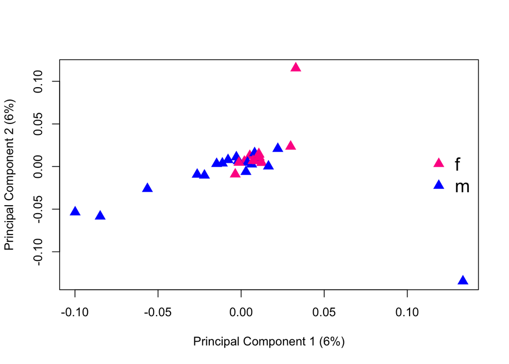

```r
plotMDS(beta, top=10000, gene.selection="common",
        pch=17,col=c("deeppink","blue")[factor(pheno$Sex)],
        dim=c(1,2),cex=1.5)
legend("right", legend=levels(factor(pheno$Sex)),bty='n',
       cex=1.5,pch=17,col=c("deeppink","blue"))
```

Let’s look at the effect of technical variables:  
Row

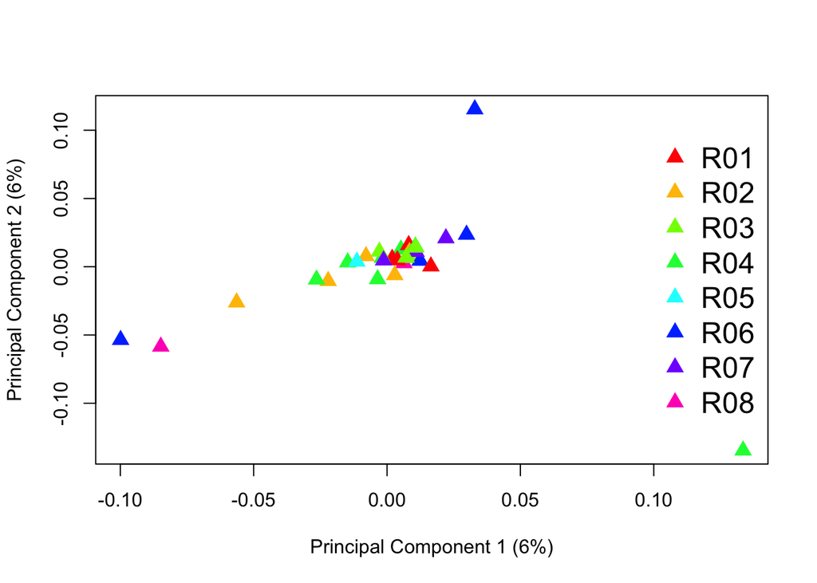

```r
cols <- rainbow(n = length(levels(factor(pheno$row))))
plotMDS(beta, top=10000, gene.selection="common",
        pch=17,col=cols[factor(pheno$row)],
        dim=c(1,2),cex=1.5)
legend("right", legend=levels(factor(pheno$row)),bty='n',
       cex=1.5,pch=17,col=cols)
```

If clustering by technical variables is present, batch effects can be adjusted for using ComBat or using covariates for batch in downstream analyses.

Example of ComBat  
Impute missing Beta-values (ComBat will produce an error with missingness)

```r
sum(is.na(beta))
betas.impute = champ.impute(beta=beta, pd=pheno, k=5, ProbeCutoff=0.2, SampleCutoff=0.1)
betas.impute = betas.impute$beta
```

Run ComBat

```r
batch <- factor(pheno$Sentrix_ID)
modcombat <- model.matrix(~1, data = pheno)
betaCombat <- ComBat(dat = as.matrix(betas.impute), batch = batch, mod = modcombat)
```

It would be useful to look at several traits with global variability

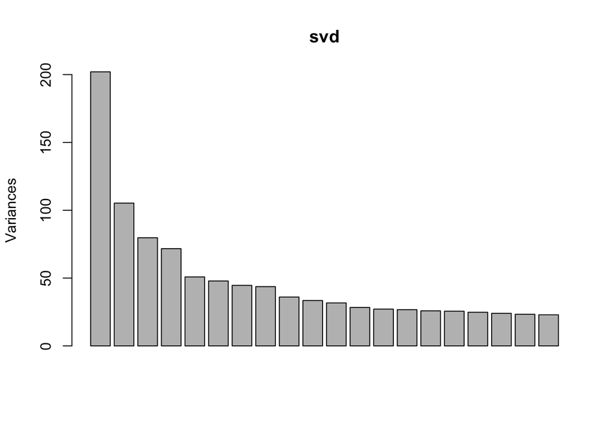

```r
cov<-data.frame(pheno[,c('smoker','Sex','CD4','CD8','NK','MO','GR','B')])
npc <- 20 # Top 20 PCs
svd <- prcomp(t(na.omit(beta)))
screeplot(svd, npc, type = "barplot")
```

```r
eigenvalue <- svd[["sdev"]]^2
prop <- (sum(eigenvalue[1:npc])/sum(eigenvalue)) * 100
cat("Top ", npc, " principal components can explain ",
    prop, "% of data \n    variation", "\n")
```

```
## Top  20  principal components can explain  83.93834 % of data
##     variation
```

```
## Analysis is running, please wait...!
```

```
## svdscreeplot.jpg was plotted
## Top  10  principal components explain  64.39 % of data
##     variation
```

```
## pcr_diag.jpg was plotted
```

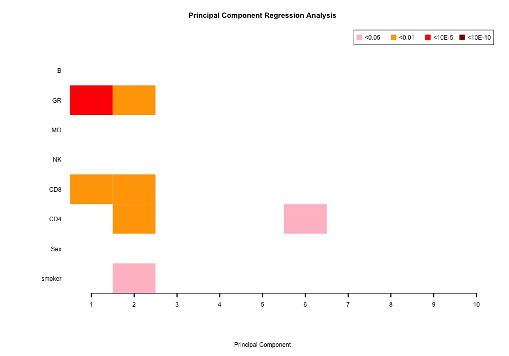

```r
screeplot(svd,npc,type="barplot")
pcrplot(na.omit(beta), cov, npc=10)
```

## Epigenetic Age

We are using epigenetic age predictions from the methscore function in the ENmix R package  
See: https://doi.org/10.1093/bioinformatics/btae302

Usage of methscore is detailed below, we are loading in previously generated results

```r
suppressMessages(library(ENmix))
# phenotype file requires specifically named Age and Female variables
names(pheno)[names(pheno) == "age"] <- "Age"
names(pheno)[names(pheno) == "gsm"] <- "SampleID"
pheno$Female <- ifelse(pheno$Sex == "m", 0, 1)
clocks <- methscore(beta, datPheno=pheno, fastImputation=FALSE, normalize=TRUE,
           GrimAgeComponent=NULL, UserRef=NULL, ForceUserRef=FALSE)
write.csv(clocks, "./results/methscore_predictions.csv", row.names = FALSE)
```

Check missingness of CpGs for epigenetic clocks

```r
methscore_summary <- read.csv("./results/summary_methscore_CpG.csv")
methscore_summary[1:4, c(1, 7:9)]
```

```
##    predictor nCpG_required nCpG_present nCpG_missing
## 1 HorvathAge           353          340           13
## 2   Horvath2           391          373           18
## 3  HannumAge            71           62            9
## 4 PCHorvath1         78464        72616         5848
```

Examine fit of some clocks with chronological age

```r
clocks <- read.csv("./results/methscore_predictions.csv")
```

Horvath’s panTissue clock

```r
cor.test(clocks$Age,clocks$HorvathAge)
```

```
##
##  Pearson's product-moment correlation
##
## data:  clocks$Age and clocks$HorvathAge
## t = 16.659, df = 28, p-value = 4.611e-16
## alternative hypothesis: true correlation is not equal to 0
## 95 percent confidence interval:
##  0.9027893 0.9776531
## sample estimates:
##       cor
## 0.9530739
```

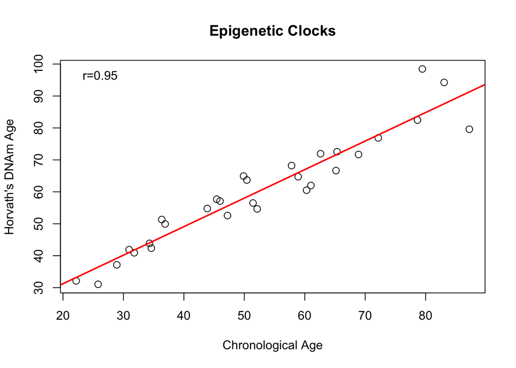

```r
plot(clocks$Age,clocks$HorvathAge,pch=21,xlab="Chronological Age",
     ylab="Horvath's DNAm Age",cex=1.2, main="Epigenetic Clocks")
legend("topleft",legend=paste0("r=",round(cor(clocks$Age,clocks$HorvathAge),2)),bty="n")
abline(lm(clocks$HorvathAge~clocks$Age),col="red",lw=2)
```

PC GrimAge

```r
cor.test(clocks$Age,clocks$PCGrimAge)
```

```
##
##  Pearson's product-moment correlation
##
## data:  clocks$Age and clocks$PCGrimAge
## t = 13.937, df = 28, p-value = 4.037e-14
## alternative hypothesis: true correlation is not equal to 0
## 95 percent confidence interval:
##  0.8664504 0.9688411
## sample estimates:
##      cor
## 0.934889
```

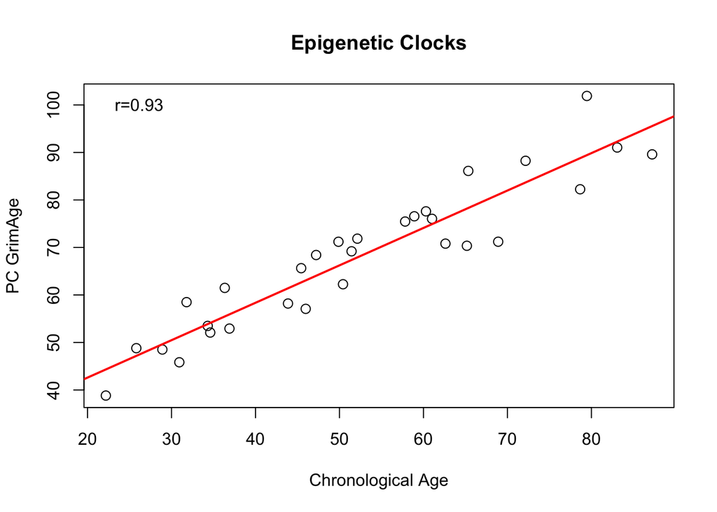

```r
plot(clocks$Age,clocks$PCGrimAge,pch=21,xlab="Chronological Age",
     ylab="PC GrimAge",cex=1.2, main="Epigenetic Clocks")
legend("topleft",legend=paste0("r=",round(cor(clocks$Age,clocks$PCGrimAge),2)),bty="n")
abline(lm(clocks$PCGrimAge~clocks$Age),col="red",lw=2)
```

DNAmTL

```r
cor.test(clocks$Age,clocks$DNAmTL)
```

```
##
##  Pearson's product-moment correlation
##
## data:  clocks$Age and clocks$DNAmTL
## t = -7.6219, df = 28, p-value = 2.653e-08
## alternative hypothesis: true correlation is not equal to 0
## 95 percent confidence interval:
##  -0.9118583 -0.6550262
## sample estimates:
##        cor
## -0.8214459
```

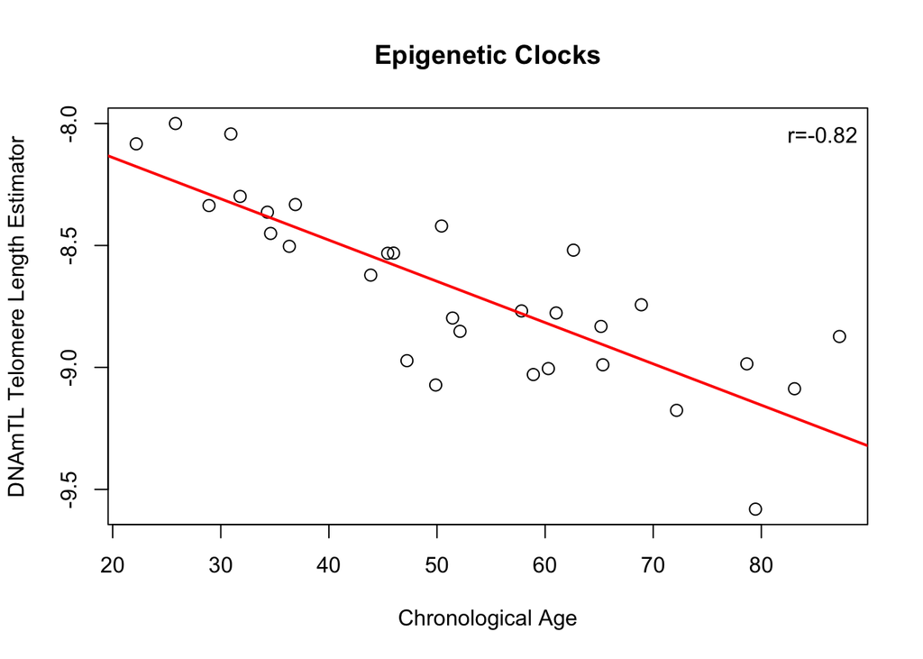

```r
plot(clocks$Age,clocks$DNAmTL,pch=21,xlab="Chronological Age",
     ylab="DNAmTL Telomere Length Estimator",cex=1.2, main="Epigenetic Clocks")
legend("topright",legend=paste0("r=",round(cor(clocks$Age,clocks$DNAmTL),2)),bty="n")
abline(lm(clocks$DNAmTL~clocks$Age),col="red",lw=2)
```

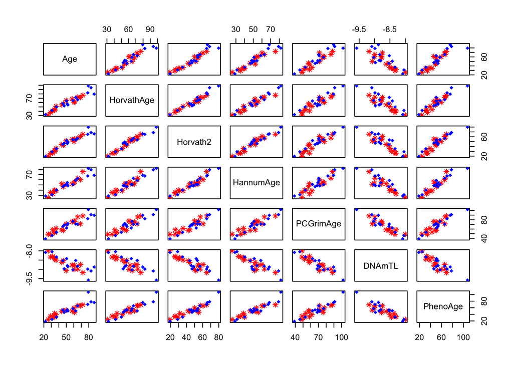

```r
group <- NA
group[pheno$smoker==1] <- 1
group[pheno$smoker==0] <- 2
pairs(~ Age + HorvathAge + Horvath2 + HannumAge +
        PCGrimAge + DNAmTL + PhenoAge,
      col = c("red","blue")[group],
      pch = c(8, 18)[group],
      data = clocks)
```

### Age Acceleration Residuals

Calculate EAA measures as residuals from a regression of  
$Epigenetic Age Measure \sim Chronological Age$

*Note the methscore function also calculates residuals for each clock measure*

```r
clocks$Horvath_resid <- residuals(lm(HorvathAge ~ Age, data = clocks))
clocks$PCGrimAge_resid <- residuals(lm(PCGrimAge ~ Age, data = clocks))
clocks$PCPACKYRS_resid <- residuals(lm(PCPACKYRS ~ Age, data = clocks))
```

Differences by Smoking status

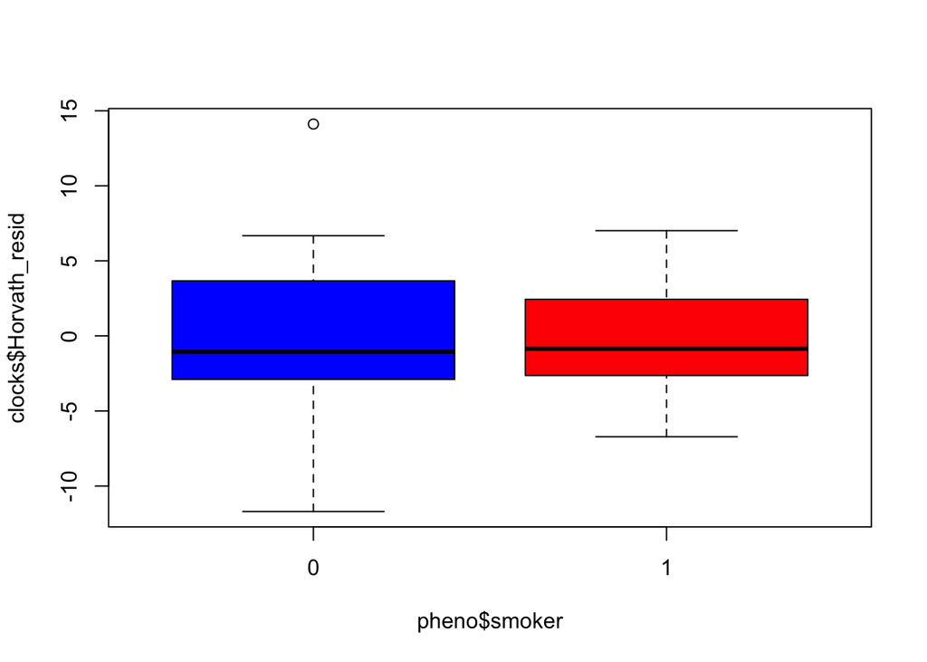

```r
boxplot(clocks$Horvath_resid ~ pheno$smoker, col=c("blue","red"))
```

```r
wilcox.test(clocks$Horvath_resid ~ pheno$smoker)
```

```
##
##  Wilcoxon rank sum exact test
##
## data:  clocks$Horvath_resid by pheno$smoker
## W = 121, p-value = 0.7437
## alternative hypothesis: true location shift is not equal to 0
```

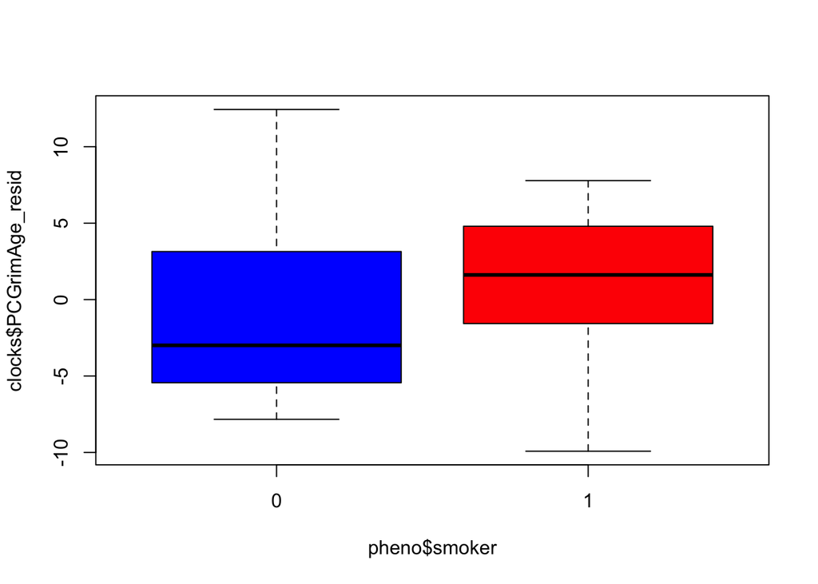

```r
boxplot(clocks$PCGrimAge_resid ~ pheno$smoker, col=c("blue","red"))
```

```r
wilcox.test(clocks$PCGrimAge_resid ~ pheno$smoker)
```

```
##
##  Wilcoxon rank sum exact test
##
## data:  clocks$PCGrimAge_resid by pheno$smoker
## W = 80, p-value = 0.1873
## alternative hypothesis: true location shift is not equal to 0
```

Smoking packyears estimator component of PC GrimAge

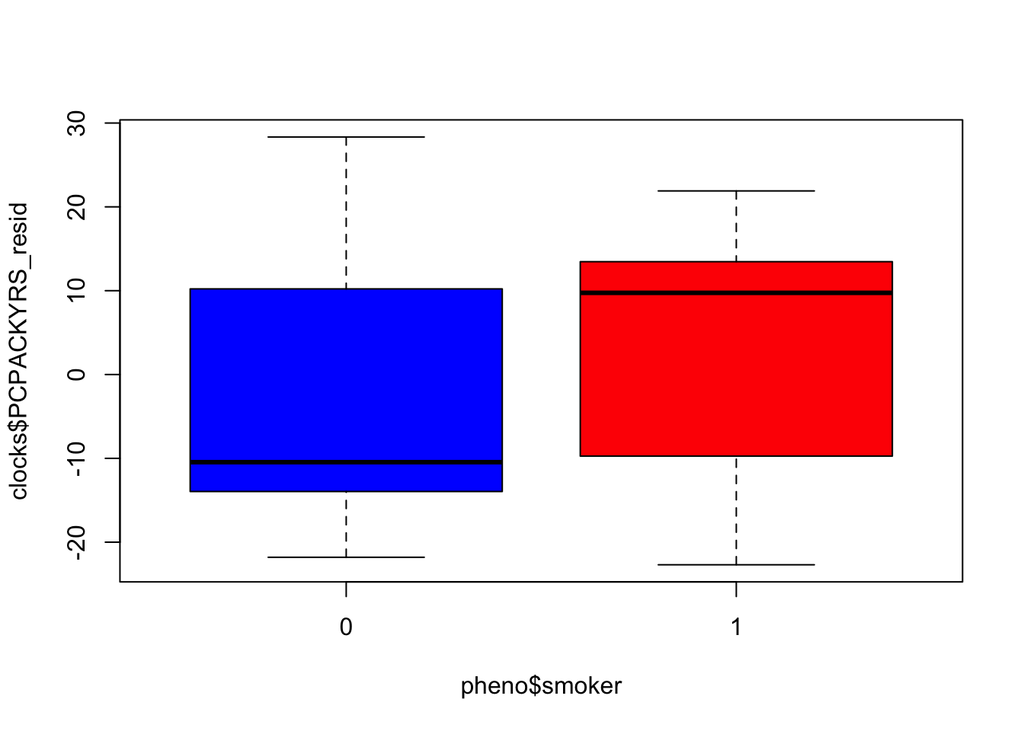

```r
boxplot(clocks$PCPACKYRS_resid ~ pheno$smoker, col=c("blue","red"))
```

```r
wilcox.test(clocks$PCPACKYRS_resid ~ pheno$smoker)
```

```
##
##  Wilcoxon rank sum exact test
##
## data:  clocks$PCPACKYRS_resid by pheno$smoker
## W = 82, p-value = 0.2169
## alternative hypothesis: true location shift is not equal to 0
```

### Protein Methylation Risk Scores

methscore also features a number of epigenetic predictors of other traits including methylation risk scores of the circulating proteome  
https://pmc.ncbi.nlm.nih.gov/articles/PMC8880990/

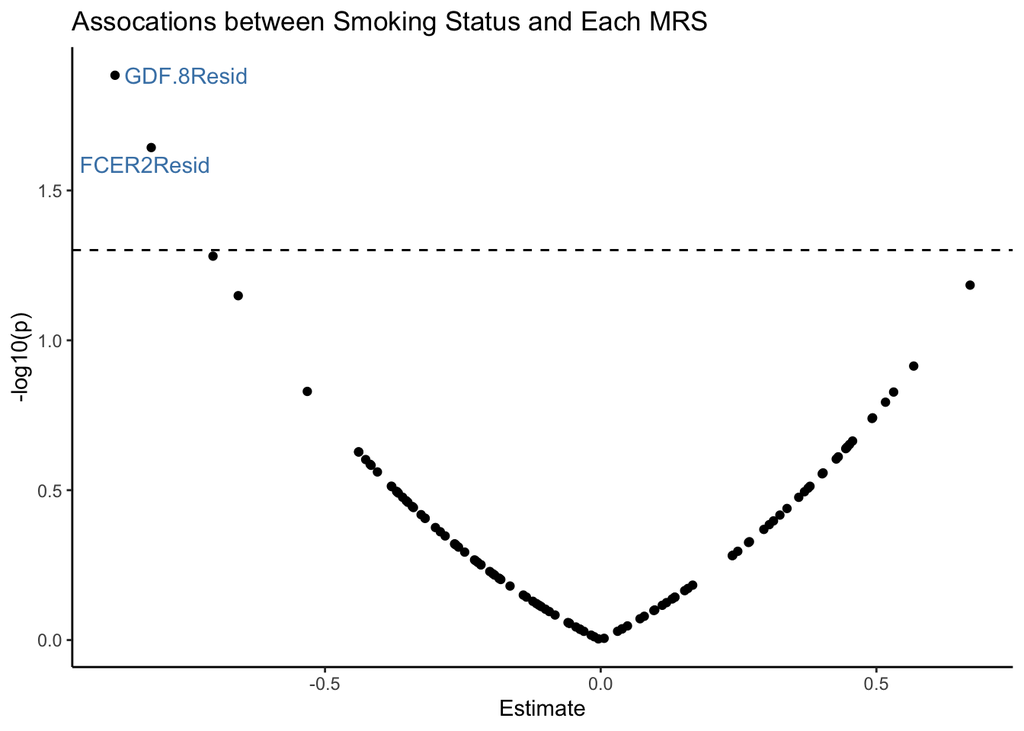

```r
proteins <- clocks[, 210:318]
for(i in 1:ncol(proteins)){
  proteins[, i] <- scale(proteins[, i])
  fit <- glm(proteins[, i] ~ pheno$smoker)
  sums <- summary(fit)$coefficients[2, ]
  sums[5] <- colnames(proteins)[i]
  if(i == 1){fullsums <- sums}
  else{fullsums <- rbind(sums, fullsums)}
}
fullsums <- as.data.frame(fullsums)
colnames(fullsums) <- c("Estimate", "SE", "t", "p", "Name")
fullsums$Estimate <- as.numeric(fullsums$Estimate); fullsums$p <- as.numeric(fullsums$p)
fullsums$sig <- ifelse(fullsums$p < 0.05, fullsums$Name, "")
library(ggplot2)
ggplot(fullsums) +
  geom_point(aes(x = Estimate, y = -log10(p))) + theme_classic() +
  ggrepel::geom_text_repel(aes(x = Estimate, y = -log10(p), label = sig), color = "steelblue") +
  geom_hline(yintercept = -log10(0.05), linetype = "dashed") +
  ggtitle("Assocations between Smoking Status and Each MRS")
```

There are a number of other resources for calculating epigenetic clocks

- methylCIPHER R package: https://github.com/MorganLevineLab/methylCIPHER
  - Another comprehensive GitHub package
- Horvath/Clock Foundation Online Calculator: http://dnamage.genetics.ucla.edu/
  - Most common original method. Option for submitting IDATs now
- methylclock R package: https://bioconductor.org/packages/release/bioc/html/methylclock.html
  - Another comprehensive R package
- Bio-learn package: https://bio-learn.github.io/
  - Python-based resource for clock calculations
  - Also the primary public implementation of GrimAge/GrimAge2

## Predicting smoking with EpiSmokEr

See [Bollepalli, Sailalitha, et al. Epigenomics 2019](https://pubmed.ncbi.nlm.nih.gov/31466478/).

```r
suppressMessages(require(EpiSmokEr))
# Make sure rows of pheno match betas column names
rownames(pheno)<-pheno$gsm
identical(colnames(beta),rownames(pheno))
```

```
## [1] TRUE
```

pheno needs a column for sex,in the format of 1 and 2 representing men and women respectively

```r
pheno$sex<-ifelse(pheno$sex=="m",1,2)
```

121 CpGs are used selected by LASSO along with Sex to get 3 categories (current, former and never smokers)

```r
result <- epismoker(dataset=beta, samplesheet = pheno, method = "SSt")
```

```
## <<<<< Predicting Smoking Statuses >>>>>
```

```
## Replacing samples with NAs in methylation data with 0.5.
```

```
## Dataset has 86 of 121 CpGs required for smoking status estimation.
```

```
## Replacing samples with NAs in methylation data with 0.5.
```

```
## Dataset has 86 of 121 CpGs required for smoking status estimation.
```

```
## Replacing samples with NAs in methylation data with 0.5.
```

```
## Dataset has 86 of 121 CpGs required for smoking status estimation.
```

```
## <<<<< Prediction of Smoking Statuses Completed >>>>>
```

Let’s look how well the prediction performed

```r
table(pheno$smoker,result$PredictedSmokingStatus)
```

```
##
##     Current Smoker Former Smoker Never Smoker
##   0              0            14            1
##   1             15             0            0
```

clear environment

```r
rm(list = ls()); gc()
```

```
##            used  (Mb) gc trigger   (Mb) limit (Mb)  max used   (Mb)
## Ncells 15608078 833.6   30688474 1639.0         NA  30688474 1639.0
## Vcells 28562577 218.0  171576106 1309.1      65536 211038213 1610.1
```

End of script 02